# Reproducible Research: Peer Assessment 1

This document outlines the steps to analyze anonymized data collected at 5-minute intervals from a personal activity monitoring device for October and November, 2012, including the number of steps taken.

## Loading and preprocessing the data

### Load Required Packages

First, will load required packages for this document and analysis.

```r
        ## Load Required Packages
        require(dplyr)
```

```r
        require(ggplot2)
        require(knitr)
        require(mice)
```

The next step is to load and read the data from the forked repository from [Github](https://github.com/kpivert/RepData_PeerAssessment1).

```r
        ## Unzip activity.zip
        activityData <- unzip("/Users/kpivert/RepData_PeerAssessment1/activity.zip")

        ## Read Data
        stepData <- read.csv(activityData, na.strings = "NA")
```

Finally, will examine the structure of the `stepData` dataframe.

```r
        str(stepData)
```

```
## 'data.frame':    17568 obs. of  3 variables:
##  $ steps   : int  NA NA NA NA NA NA NA NA NA NA ...
##  $ date    : Factor w/ 61 levels "2012-10-01","2012-10-02",..: 1 1 1 1 1 1 1 1 1 1 ...
##  $ interval: int  0 5 10 15 20 25 30 35 40 45 ...
```

```r
        summary(stepData)
```

```
##      steps                date          interval
##  Min.   :  0.00   2012-10-01:  288   Min.   :   0.0
##  1st Qu.:  0.00   2012-10-02:  288   1st Qu.: 588.8
##  Median :  0.00   2012-10-03:  288   Median :1177.5
##  Mean   : 37.38   2012-10-04:  288   Mean   :1177.5
##  3rd Qu.: 12.00   2012-10-05:  288   3rd Qu.:1766.2
##  Max.   :806.00   2012-10-06:  288   Max.   :2355.0
##  NA's   :2304     (Other)   :15840
```

## What is mean total number of steps taken per day?

1. Make a histogram of the total number of steps taken each day. Per instructions, “NA” values will be omitted from analysis.
- Will calculate total number of steps by day and produce a histogram of total steps by day.

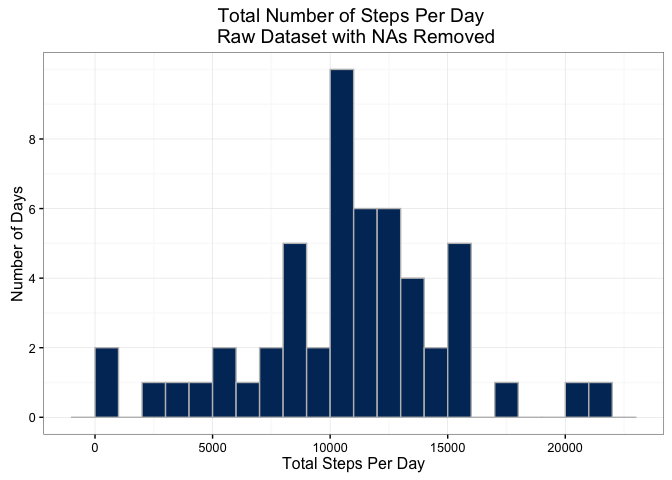

```r
        ## Calculate Total Steps By Date

        totalSteps <- aggregate(steps ~ date, data = stepData, sum, na.action = na.omit)

        ## Create Histogram Using ggplot2

        totalStepsHist <- ggplot(totalSteps, aes(steps))

        totalStepsHist + geom_histogram(binwidth = 1000, color="grey",
            fill ="#003366") +
          theme_bw()+
          ylab("Number of Days")+
          xlab("Total Steps Per Day")+
          scale_y_continuous(breaks = seq(0,8,2),
                             labels = as.character(seq(0,8,2)))+
          ggtitle("Total Number of Steps Per Day \n Raw Dataset with NAs Removed")
```

2. Calculate and report the mean and median total number of steps taken per day

- Will calculate overall mean and median steps per day across 2-month data period.

```r
      ## Mean Steps Per Day for 2-Month Period

      mean(totalSteps$steps, na.rm = TRUE)
```

```
## [1] 10766.19
```

```r
      ## Median Steps Per Day for 2-Month Period

      median(totalSteps$steps, na.rm = TRUE)
```

```
## [1] 10765
```

Mean number of steps per day: 10766.19

Median number of steps per day: 10765

## What is the average daily activity pattern?

1. Make a time series plot (i.e. type = “l”) of the 5-minute interval (x-axis) and the average number of steps taken, averaged across all days (y-axis)
- Determine average number of steps by time interval
- Create a time series plot

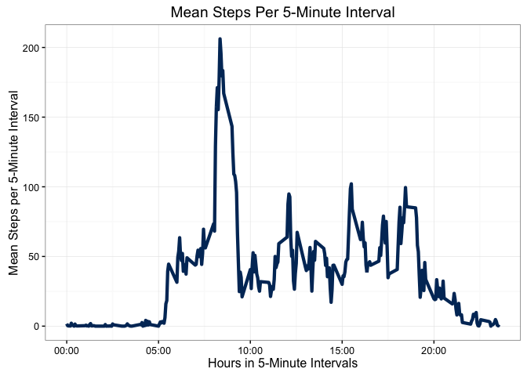

```r
        ## Mean steps per interval
        averageInt <- aggregate(steps ~ interval, data = stepData, mean, na.rm = TRUE)

        ## Create time series plot

        averageIntPlot <- ggplot(averageInt, aes(x=interval, y=steps))

        averageIntPlot + geom_line(color="#003366", size = 1.5)+
          theme_bw()+
          ylab("Mean Steps per 5-Minute Interval")+
          xlab("Hours in 5-Minute Intervals")+
          ggtitle("Mean Steps Per 5-Minute Interval")+
          scale_x_continuous(breaks=seq(0,2000,500), labels = c("00:00", "05:00",
                "10:00", "15:00", "20:00"))
```

2. Which 5-minute interval, on average across all the days in the dataset, contains the maximum number of steps?
- Determine max 5-minute interval

```r
        ## What is the 5-minute interval that has the largest mean number of steps
        ## across the 2-month period?

        averageInt[which.max(averageInt$steps),1] ## Interval 835 or 8:35 a.m.
```

```
## [1] 835
```

Maximum number of steps in 5-minute interval ocurred at 8:35 a.m. (or 0835).

## Imputing missing values

1. Calculate and report the number of `NA` values.

```r
        ## Determine number of NA values in dataframe

        apply(is.na(stepData),2,sum)
```

```
##    steps     date interval
##     2304        0        0
```

2. Devise a strategy for filling in all of the missing values in the dataset. Create a new dataset that is equal to the original dataset but with the missing data filled in.
- Will use `MICE` package with default settings to complete missing values

```r
        imputedStepData <- complete(mice(stepData, seed = 123))
        ## Verify no NAs remain
        sapply(imputedStepData, function(x) sum(is.na(x)))
```

```
##    steps     date interval
##        0        0        0
```

3. Make a histogram of the total number of steps taken each day.

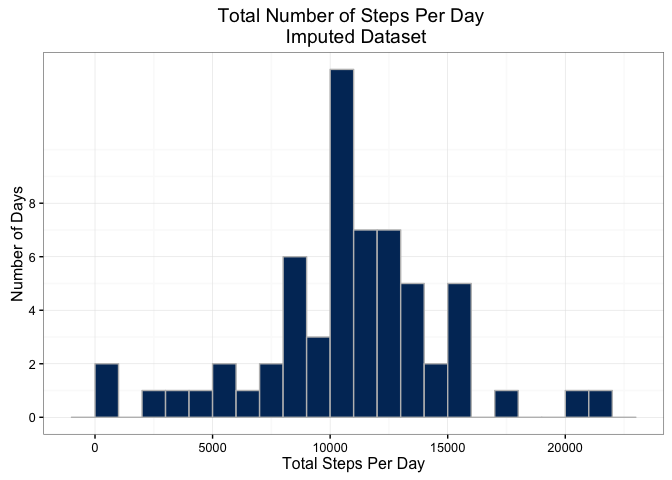

```r
        ## Calculate Total Steps By Date in Imputed Dataset

        totalImputedSteps <- aggregate(steps ~ date, data = imputedStepData, sum)

        ## Create Histogram Using ggplot2

        totalImputedStepsHist <- ggplot(totalImputedSteps, aes(steps))

        totalImputedStepsHist + geom_histogram(binwidth = 1000, color="grey", fill ="#003366") +
          theme_bw()+
          ylab("Number of Days")+
          xlab("Total Steps Per Day")+
          scale_y_continuous(breaks = seq(0,8,2),
                             labels = as.character(seq(0,8,2)))+
          ggtitle("Total Number of Steps Per Day \n Imputed Dataset")
```

4. Calculate and report the mean and median total number of steps taken per day.
- Calculate overall mean and median steps per day for imputed dataset across 2-month data period.

```r
      ## Mean Steps Per Day for 2-Month Period: Imputed Dataset

      mean(totalImputedSteps$steps)
```

```
## [1] 10768.62
```

```r
      ## Median Steps Per Day for 2-Month Period: Imputed Dataset

      median(totalImputedSteps$steps)
```

```
## [1] 10600
```

#### Do these values differ from the estimates from the first part of the assignment?

- **Raw Datset Mean Steps Per Day:** 10766.19
- **Imputed Dataset Mean Steps Per Day:** 10768.62

*There is a minimal difference in mean steps per day between the raw and imputed dataset.*

- **Raw Datset Median Steps Per Day:** 10765
- **Imputed Dataset Median Steps Per Day:** 10600

*The median steps per day between the raw and imputed dataset differed more substantially than the mean, by 165 steps.*

## Are there differences in activity patterns between weekdays and weekends?

1. Create a new factor variable in the dataset with two levels – “weekday” and “weekend” indicating whether a given date is a weekday or weekend day.

```r
        ## Create new factor in imputed dataset

        ## Convert date data to date

        imputedStepData$date <- as.Date(imputedStepData$date)

        ## Add Days of Week Column to Dataframe

        imputedStepData$days <- weekdays(imputedStepData$date)

        ## Add New Factor

        mtwrf <- c("Monday", "Tuesday", "Wednesday", "Thursday", "Friday")

        imputedStepData$wkDaywkEnd <- ifelse(imputedStepData$days %in% mtwrf, TRUE, FALSE) ## TRUE = Weekday, FALSE = Weekend

        imputedStepData$wkDaywkEnd <- factor(imputedStepData$wkDaywkEnd, labels = c("Weekend", "Weekday"))
```

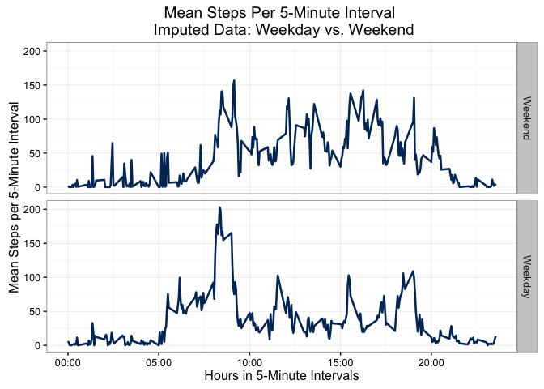

```r
        ## Mean steps per interval: Imputed Dataset
        averageIntImpute <- aggregate(steps ~ interval + wkDaywkEnd, data = imputedStepData, mean)

        ## Create time series plot

        averageIntImputePlot <- ggplot(averageIntImpute, aes(x=interval, y=steps))

        averageIntImputePlot + geom_line(color="#003366", size = 0.9)+
          facet_grid(wkDaywkEnd ~ .)+
          theme_bw()+
          ylab("Mean Steps per 5-Minute Interval")+
          xlab("Hours in 5-Minute Intervals")+
          ggtitle("Mean Steps Per 5-Minute Interval \n Imputed Data: Weekday vs. Weekend")+
          scale_x_continuous(breaks=seq(0,2000,500), labels = c("00:00", "05:00",
                "10:00", "15:00", "20:00"))
```